# Yu-Gi-Oh! Exploration

### It is time to duel!

#### Yu-Gi-Oh is the most popular trading card game. It contains more than 6000 cards to play with and to make a deck from.

#### We will explore the Yu-Gi-Oh! cards and try to understand and discover the relations between card types

## Data Exploration

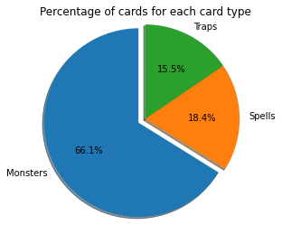

### First, let's investigate monsters.

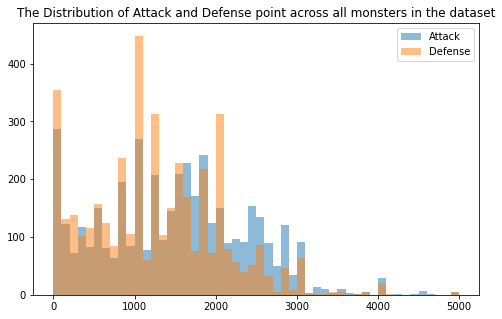

### Let's find the relation between the attack and defense points.

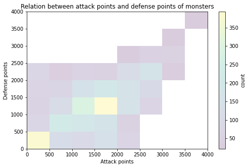

### The trend shows that monsters have nearly equal attack and defense points.

### Next, let's take a look at monster levels..

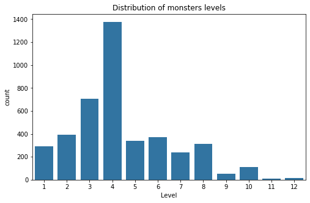

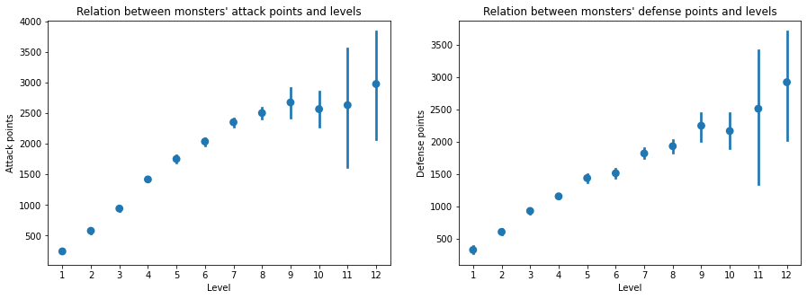

### The mean attack and defense points increase with the increase of the level with high variabiity in both attack and defense points with last 4 levels.

## Does the Monster type do anything with attack and defense?

### First, we'll take a look at the monster races and the most common ones.

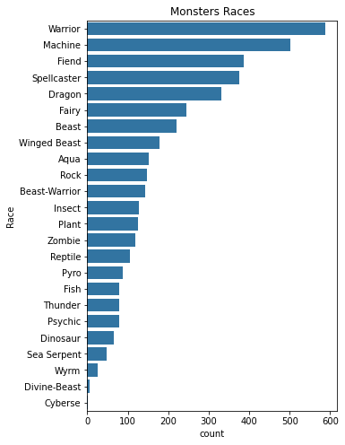

### Now let's see the relation between the most common 7 monster races and their attack and defense.

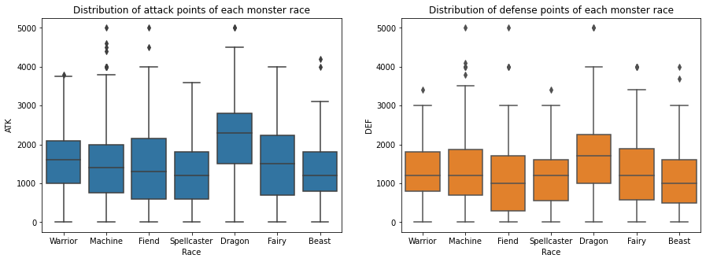

### Dragon-Type monsters have the highest average attack and defense, while Fiend and Fairy-Type monsters have a larger variaty in attack and defense points.

### Finally, We will investigate the monster types and attributes.

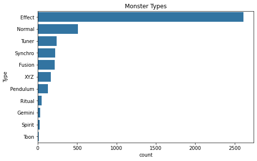

### I will continue with the top 6 types to explore better further.

### We'll take a look at the monster attributes.

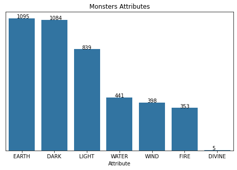

### Let's see the attack points in every attribute and the top 6 common monster card type.

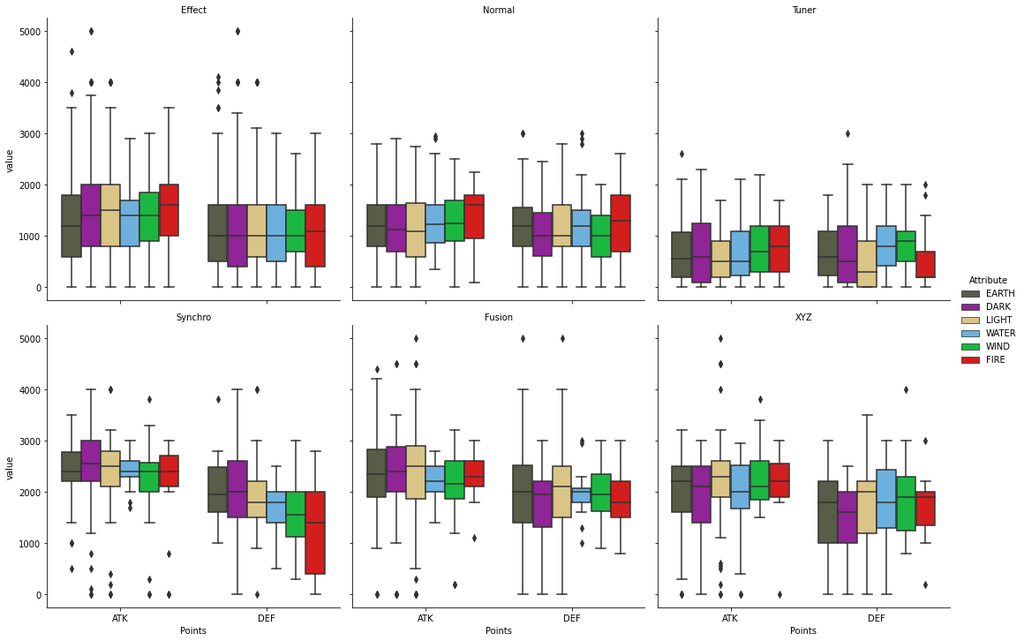

### Fusion, Synchro and XYZ monsters have higher attacks than the other types, while Tuner monsters have the lowest.

## Second, let's investigate the Spell and Trap cards..

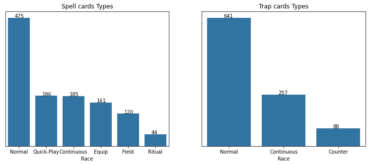

# Conclusion

#### The data gave us a brief introduction for the game and their cards. Monsters are the majority of cards, spell and traps cards comes next.

# Limitations

#### Unfortunately, I couldn't introduce game ruling as the dataset lacks card effects which would have made a drastic change in our analysis and finding more complex relations and game strategies.